# Worksheet 1 - Scientific Visualization MVE080/MMG640

## Basics in Python, Jupyter, and Matplotlib

Name: *Elvina Fahlgren*

This is the first worksheet in the course *Scientific Visualization*. The purpose is to help you get acquainted with Python (version 3), Jupyter, and Matplotlib. This Jupyter notebook has three functions:

1. It describes the tasks.
2. It (sometimes) provides coding templates that you can use as a basis for your own code.
3. It is a template also for the report that you upload in Canvas.

The tasks are of various types: some are to read some text and then comment on it (no coding), and some are about creating visualizations using Matplotlib. Once you're finished with all the tasks, export this document as an HTML-file and upload it in Canvas. You are encouraged to discuss problems and solutions with your fellow students (in the class-room but also on CampusWire), but each student must solve all tasks by themselves and hand-in their own report. Notice that Jupyter notebooks use [Markdown](https://docs.github.com/en/github/writing-on-github/getting-started-with-writing-and-formatting-on-github/basic-writing-and-formatting-syntax#links) for writing text cells. Make sure you understand the basics. Later on you can also include $\LaTeX$ in your Markdown cells.

Throughout the assignment you shall use a Python workflow. If you are completely new to Python, take a look at this page. Python can do essentially all that MATLAB can, plus more. In this course we shall use Python in different contexts, starting with the [Jupyter Notebook interface](https://jupyter-notebook.readthedocs.io/en/stable/notebook.html). On the Chalmers Linux computers, a Jupyter Notebook session is started by opening a terminal and running the commands:

```
    >> source /chalmers/groups/anaconda/anaconda3/bin/activate
    >> jupyter notebook
```

Matrices and arrays are handled through the NumPy module. [Learn here](https://docs.scipy.org/doc/numpy/user/numpy-for-matlab-users.html) how NumPy is different from MATLAB.

## Setup

Before we begin it is necessary to load a few Python modules that are needed. We can do that with the following commands (which only have to be run once, unless you restart the Jupyter kernel in which case you have to re-run them).

```python
import numpy as np
import matplotlib.pyplot as plt
import matplotlib as mpl

import matplotlib.cm as cm
import matplotlib.cbook as cbook
from matplotlib.path import Path
from matplotlib.patches import PathPatch

from matplotlib.colors import BoundaryNorm
from matplotlib.ticker import MaxNLocator

import matplotlib.path as mpath
import matplotlib.patches as mpatches

from matplotlib import cm
from matplotlib.ticker import LinearLocator

import matplotlib.gridspec as gridspec
from matplotlib.patches import Ellipse

from matplotlib.ticker import MaxNLocator
from collections import namedtuple
from matplotlib.widgets import Slider, Button
import matplotlib.dates as mdates

import subprocess
import sys
import re

import matplotlib

# The line below makes the plots somewhat interactive by choosing a different "backend".
%matplotlib inline
#notebook
```

## Task 1

Read Chapter 1-3 of [Fundamentals of Data Visualizations](https://clauswilke.com/dataviz/), then answer the questions below.

### Question 1.1

Describe the visualization concept *scales*.

### Answer 1.1

The concept *scales* defines a specific mapping between data values and aesthetics values. For example, numbers could mapped onto position scale, temperatures onto color scale and weight onto size scale.

### Question 1.2

In Figures 2.3 and 2.4 the same data is visualized in two different ways. Discuss the pros and cons of the two approaches. Which one do you prefer and why?

### Answer 1.2

In Figure 2.3 the temperature values are easy to interpret since thier values are represented on an clearly marked y-axis. A realitvely accurate temperature value can be read without much hassle. This is not the case for Figure 2.4, as intrepting the shades of colors in relation to their exact value is more difficult. A negative aspect of Figure 2.3 is that if more cities were to be added, the graph would become quite congested which would make it harder to read.

Figure 2.4 is better at giving a quick overview of the temperature differences between more cities, as the intepreter can quickly get a sense of how cold or hot a city is at a specific month. This is mainly due to the color shades which relates very well to coldness(darker blue) or heat(brighter yellow), which is one of the biggest positives of Figure 2.4. The opposite can be said for Figure 2.3, as at a quick glance the reader would not know what the data represents, as there is no personal connection to the temperatures like in Figure 2.4.

Personally, I prefer Figure 2.3 since I highly prioritize clarity.

### Question 1.3

Describe situations when *nonlinear axes* might be useful. When should they not be used?

### Answer 1.3

Nonlinear axes are useful when representing data that has resulted from using multiplication or division. For example when their is an exponential growth or decline, as the stock market. Nonlinear exes shoud not be used when there is linear growth or decline.

### Question 1.4

In which situations could a *polar coordinate system* be useful?

### Answer 1.4

A polar coordinate system could be useful when representing data that is logically joined at both ends of the scale. Examples for when to use polar coordinate system, is when visualizing locations in relation to a center point, such as the solar system and aviation radiar.

## Task 2

Go to the Matplotlib [tutorial page](https://matplotlib.org/stable/tutorials/index.html) and work through the first "Usage Guide" tutorial. Add cells below for doing the tasks. Make sure you understand the anatomy of a Matplotlib visualization.

### A simple example

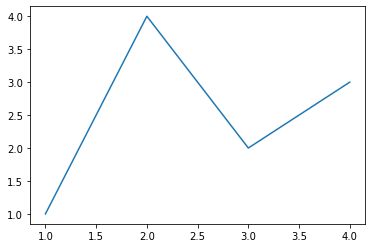

```python
fig, ax = plt.subplots()
ax.plot([1, 2, 3, 4], [1, 4, 2, 3])
```

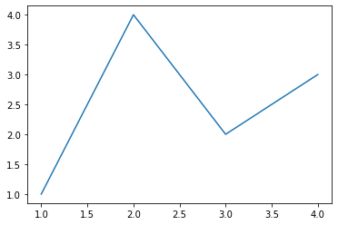

```python
plt.plot([1, 2, 3, 4], [1, 4, 2, 3])
```

### Parts of Figure

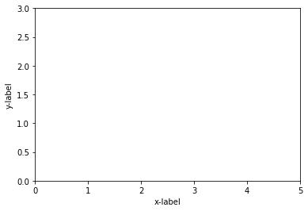

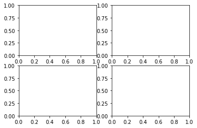

```python
fig = plt.figure()
fig, ax = plt.subplots()
fig, axs = plt.subplots(2, 2)

ax.set_xlim(0, 5)
ax.set_ylim(0, 3)

ax.set_ylabel("y-label")
ax.set_xlabel("x-label")
```

### The object-oriented interface and the pyplot interface

#### OO-style

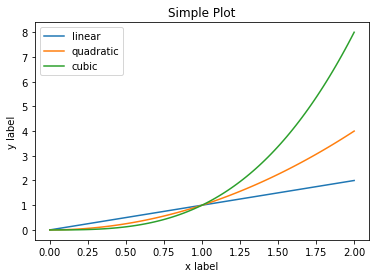

```python
x = np.linspace(0, 2, 100)

fig, ax = plt.subplots()
ax.plot(x, x, label='linear')
ax.plot(x, x**2, label='quadratic')
ax.plot(x, x**3, label='cubic')
ax.set_xlabel('x label')
ax.set_ylabel('y label')
ax.set_title("Simple Plot")
ax.legend()
```

#### Pyplot-style

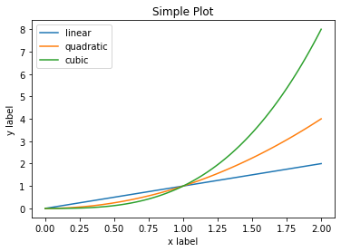

```python
x = np.linspace(0, 2, 100)

plt.plot(x, x, label='linear')
plt.plot(x, x**2, label='quadratic')
plt.plot(x, x**3, label='cubic')
plt.xlabel('x label')
plt.ylabel('y label')
plt.title("Simple Plot")
plt.legend()
```

#### Using def to plot graph

```python
def my_plotter(ax, data1, data2, param_dict):

    out = ax.plot(data1, data2, **param_dict)
    return out
```

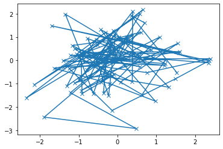

```python
data1, data2, data3, data4 = np.random.randn(4, 100)
fig, ax = plt.subplots(1, 1)
my_plotter(ax, data1, data2, {'marker': 'x'})
```

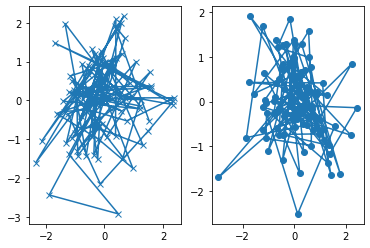

```python
fig, (ax1, ax2) = plt.subplots(1, 2)
my_plotter(ax1, data1, data2, {'marker': 'x'})
my_plotter(ax2, data3, data4, {'marker': 'o'})
```

### Interactive mode

#### Interactive example

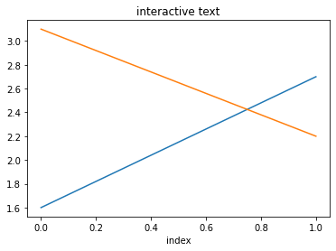

```python
plt.ion()
plt.plot([1.6,2.7])

plt.title("interactive text")
plt.xlabel("index")

ax = plt.gca()
ax.plot([3.1, 2.2])
```

#### Non-interactive example

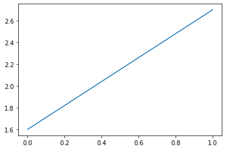

```python
plt.ioff()
plt.plot([1.6, 2.7])
```

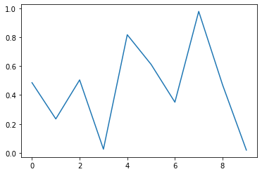

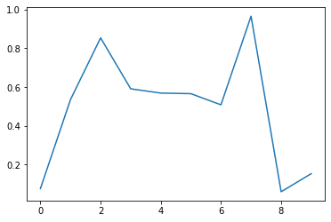

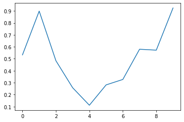

```python
plt.ioff()
for i in range(3):
    plt.plot(np.random.rand(10))
    plt.show()
```

### Performanece

#### Line segment simplification

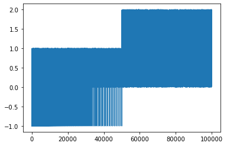

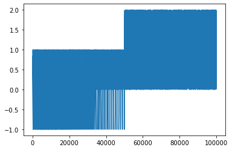

```python
# Setup, and create the data to plot
y = np.random.rand(100000)
y[50000:] *= 2
y[np.geomspace(10, 50000, 400).astype(int)] = -1
mpl.rcParams['path.simplify'] = True

mpl.rcParams['path.simplify_threshold'] = 0.0
plt.plot(y)
plt.show()

mpl.rcParams['path.simplify_threshold'] = 1.0
plt.plot(y)
plt.show()
```

#### Marker simplification

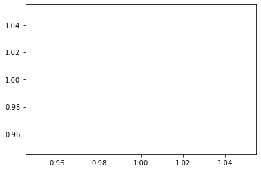

```python
plt.plot(1, 1, markevery=10)
```

#### Splitting lines into smaller chunks

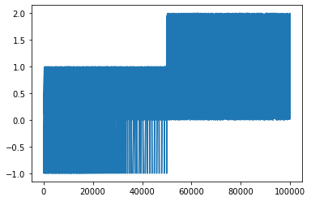

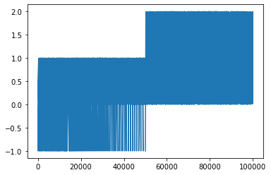

```python
mpl.rcParams['path.simplify_threshold'] = 1.0

# Setup, and create the data to plot
y = np.random.rand(100000)
y[50000:] *= 2
y[np.geomspace(10, 50000, 400).astype(int)] = -1
mpl.rcParams['path.simplify'] = True

mpl.rcParams['agg.path.chunksize'] = 0
plt.plot(y)
plt.show()

mpl.rcParams['agg.path.chunksize'] = 10000
plt.plot(y)
plt.show()
```

#### Using the *fast* style

```python
#import matplotlib.style as mplstyle
#mplstyle.use('fast')
#mplstyle.use(['dark_background', 'ggplot', 'fast'])
```

### Question 2.1

Describe with your own words what in Matplotlib is meant by a Figure, Axes, Axis, and Artist.

### Answer 2.1

The Figure is the object you can add one or several Axes to. Axes could be described as the Figures child. The Axes itself is the object which contains the space for the data and holds x and y labels. The Axes contains Axis objects (two or three). The Axis holds the limits of the graph and also visualizes the marks and mark lables on the axis. Finally, the Artist is object the defines the Figure, Axes and the Axis together.

### Question 2.2

Describe with your own words what in Matplotlib is meant by "backend". Which backend are you using now?

### Answer 2.2

A backend recieves data, for example data values, and the interpret them and performs operations and returns results.

I am currently using the backend `%matplotlib inline` because it displays the output of plotting commands inline with the frontend. A similar result could be achieved using `%matplotlib notebook` with **nbAgg**, which will also make the plots interactive.

## Task 3

Go to the Matplotlib [tutorial page](https://matplotlib.org/stable/tutorials/index.html) and work through the "Pyplot tutorial" and "Sample plots in Matplotlib" tutorial. Add cells below for the tasks.

### Intro to pyplot

```
<function matplotlib.pyplot.show(close=None, block=None)>
```

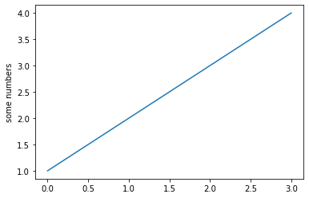

```python
plt.plot([1, 2, 3, 4])
plt.ylabel('some numbers')
plt.show
```

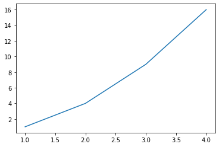

```python
plt.plot([1, 2, 3, 4], [1, 4, 9, 16])
```

#### Formatting the style of your plot

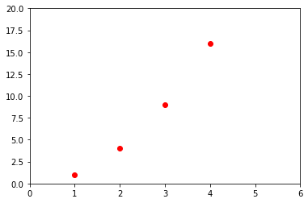

```python
plt.plot([1, 2, 3, 4], [1, 4, 9, 16], 'ro')
plt.axis([0, 6, 0, 20])
plt.show()
```

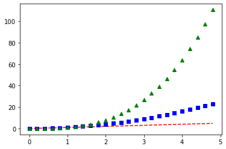

```python
# evenly sampled time at 200ms intervals
t = np.arange(0., 5., 0.2)

# red dashes, blue squares and green triangles
plt.plot(t, t, 'r--', t, t**2, 'bs', t, t**3, 'g^')
plt.show()
```

### Plotting with keyword strings

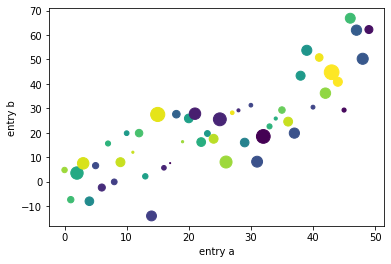

```python
data = {'a': np.arange(50),
        'c': np.random.randint(0, 50, 50),
        'd': np.random.randn(50)}
data['b'] = data['a'] + 10 * np.random.randn(50)
data['d'] = np.abs(data['d']) * 100

plt.scatter('a', 'b', c='c', s='d', data=data)
plt.xlabel('entry a')
plt.ylabel('entry b')
plt.show()
```

### Plotting with cetegorical variables

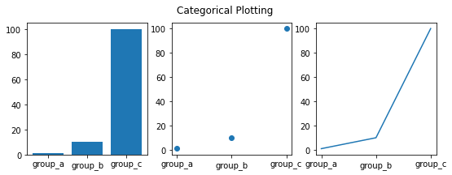

```python
names = ['group_a', 'group_b', 'group_c']
values = [1, 10, 100]

plt.figure(figsize=(9, 3))

plt.subplot(131)
plt.bar(names, values)
plt.subplot(132)
plt.scatter(names, values)
plt.subplot(133)
plt.plot(names, values)
plt.suptitle('Categorical Plotting')
plt.show()
```

### Controlling line properties

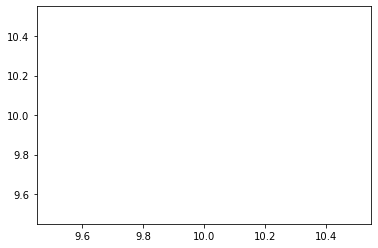

```python
plt.plot(10, 10, linewidth=2.0)
```

### Working with multiple figures and axes

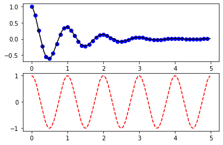

```python
def f(t):
    return np.exp(-t) * np.cos(2*np.pi*t)

t1 = np.arange(0.0, 5.0, 0.1)
t2 = np.arange(0.0, 5.0, 0.02)

plt.figure()
plt.subplot(211)
plt.plot(t1, f(t1), 'bo', t2, f(t2), 'k')

plt.subplot(212)
plt.plot(t2, np.cos(2*np.pi*t2), 'r--')
plt.show()
```

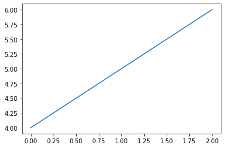

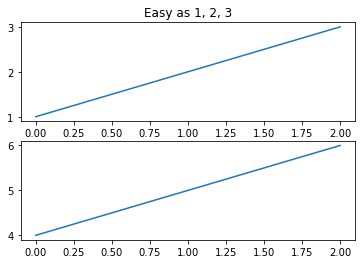

```python
plt.figure(1)                # the first figure
plt.subplot(211)             # the first subplot in the first figure
plt.plot([1, 2, 3])
plt.subplot(212)             # the second subplot in the first figure
plt.plot([4, 5, 6])


plt.figure(2)                # a second figure
plt.plot([4, 5, 6])          # creates a subplot() by default

plt.figure(1)                # figure 1 current; subplot(212) still current
plt.subplot(211)             # make subplot(211) in figure1 current
plt.title('Easy as 1, 2, 3') # subplot 211 title
```

### Working with text

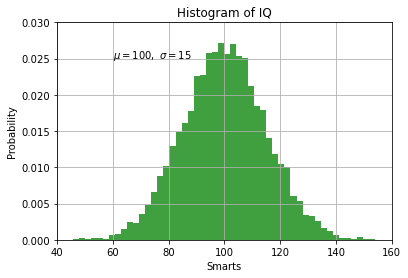

```python
mu, sigma = 100, 15
x = mu + sigma * np.random.randn(10000)

# the histogram of the data
n, bins, patches = plt.hist(x, 50, density=1, facecolor='g', alpha=0.75)


plt.xlabel('Smarts')
plt.ylabel('Probability')
plt.title('Histogram of IQ')
plt.text(60, .025, r'$\mu=100,\ \sigma=15$')
plt.axis([40, 160, 0, 0.03])
plt.grid(True)
plt.show()
```

#### Annotating text

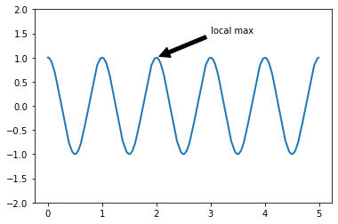

```python
ax = plt.subplot()

t = np.arange(0.0, 5.0, 0.01)
s = np.cos(2*np.pi*t)
line, = plt.plot(t, s, lw=2)

plt.annotate('local max', xy=(2, 1), xytext=(3, 1.5),
             arrowprops=dict(facecolor='black', shrink=0.05),
             )

plt.ylim(-2, 2)
plt.show()
```

### Logarithmic and other nonlinear axes

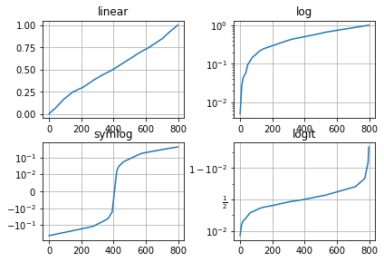

```python
# Fixing random state for reproducibility
np.random.seed(19680801)

# make up some data in the open interval (0, 1)
y = np.random.normal(loc=0.5, scale=0.4, size=1000)
y = y[(y > 0) & (y < 1)]
y.sort()
x = np.arange(len(y))

# plot with various axes scales
plt.figure()

# linear
plt.subplot(221)
plt.plot(x, y)
plt.yscale('linear')
plt.title('linear')
plt.grid(True)

# log
plt.subplot(222)
plt.plot(x, y)
plt.yscale('log')
plt.title('log')
plt.grid(True)

# symmetric log
plt.subplot(223)
plt.plot(x, y - y.mean())
plt.yscale('symlog', linthresh=0.01)
plt.title('symlog')
plt.grid(True)

# logit
plt.subplot(224)
plt.plot(x, y)
plt.yscale('logit')
plt.title('logit')
plt.grid(True)
# Adjust the subplot layout, because the logit one may take more space
# than usual, due to y-tick labels like "1 - 10^{-3}"
plt.subplots_adjust(top=0.92, bottom=0.08, left=0.10, right=0.95, hspace=0.25,
                    wspace=0.35)

plt.show()
```

### *Line Plot*

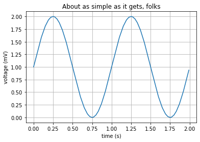

```python
# Data for plotting
t = np.arange(0.0, 2.0, 0.01)
s = 1 + np.sin(2 * np.pi * t)

fig, ax = plt.subplots()
ax.plot(t, s)

ax.set(xlabel='time (s)', ylabel='voltage (mV)',
       title='About as simple as it gets, folks')
ax.grid()

fig.savefig("test.png")
plt.show()
```